# Homework 4

**Due Date:** 2024-11-13 at 8:30 AM PT

**Name:** Joseph Matveyenko

## Preparation

1. Download the [data file](https://github.com/gabehassler/PRGS-Intro-to-ML-2024/blob/main/data/processed/svi_covid.csv) from GitHub and place it in the *data/processed* folder.

## Homework - Regression Trees

The goal of this analysis is to use a regression tree to predict the number of per-capita COVID-19 deaths in each county in the US using the SVI variables.

1. Load the data file.

```julia
using Base.Filesystem
using DataFrames
using CSV

# set working dir to main
if basename(pwd()) == "homework"
    cd(dirname(pwd()))
end

# load pre-processed data and ensure FIPS is read as a string
column_types = Dict(:fips_code => String)
dat_path = "data/processed/svi_covid.csv"
svi_covid = CSV.read(dat_path, types=column_types, DataFrame)
first(svi_covid, 3)
```

3×22 DataFrame

| Row | Column1 Int64 | fips_code String | total_cases_per_100k Float64 | total_deaths_per_100k Float64 | E_TOTPOP Int64 | EP_POV150 Float64 | EP_UNEMP Float64 | EP_HBURD Float64 | EP_NOHSDP Float64 | EP_UNINSUR Float64 | EP_AGE65 Float64 | EP_AGE17 Float64 | EP_DISABL Float64 | EP_SNGPNT Float64 | EP_LIMENG Float64 | EP_MINRTY Float64 | EP_MUNIT Float64 | EP_MOBILE Float64 | EP_CROWD Float64 | EP_NOVEH Float64 | EP_GROUPQ Float64 | EP_NOINT Float64 |
| --- | --- | --- | --- | --- | --- | --- | --- | --- | --- | --- | --- | --- | --- | --- | --- | --- | --- | --- | --- | --- | --- | --- |
| 1 | 1 | 01001 | 33888.1 | 399.925 | 58761 | 20.2 | 2.8 | 19.7 | 9.6 | 7.4 | 15.6 | 23.4 | 16.4 | 5.6 | 0.4 | 27.4 | 3.9 | 15.6 | 1.4 | 4.0 | 0.9 | 10.9 |
| 2 | 2 | 01003 | 30212.1 | 313.169 | 233420 | 18.3 | 3.4 | 23.2 | 8.4 | 9.3 | 21.2 | 21.2 | 13.9 | 4.2 | 0.8 | 17.7 | 16.6 | 10.2 | 1.9 | 2.3 | 1.5 | 10.9 |
| 3 | 3 | 01005 | 30478.0 | 418.057 | 24877 | 37.7 | 5.8 | 25.1 | 23.5 | 10.7 | 19.8 | 20.7 | 18.1 | 11.3 | 2.0 | 55.4 | 1.4 | 29.2 | 3.8 | 11.7 | 12.0 | 31.8 |

2. Write the following functions:
   - A function that fits a regression tree to data. The function should take as input the data, the outcome variable, the predictor variables, and the maximum depth of the tree. The function should return the fitted tree. *Note: Many packages have functions that penalize the complexity of the tree to avoide overfitting. You should make sure that the function you write does not use any penalization for the complexity of the tree.*
   - A function that predicts the outcome variable using a fitted tree. The function should take as input the fitted tree and the data for which to make predictions. The function should return the predicted values.
   - A function that calculates the mean squared error of the predictions. The function should take as input the predicted values and the true values. The function should return the mean squared error.

```julia
using DecisionTree
using Statistics

# function that fits regression tree to data
function fit_regression_tree(features::Array, labels::Vector, max_depth::Int)
    model = DecisionTreeRegressor(max_depth=max_depth, min_samples_leaf=1, min_samples_split=2)
    fit!(model, features, labels)
    return model
end

# function that predcicts outcome variable using a fitted tree
function predict_tree_label(fitted_tree::DecisionTreeRegressor, new_features::Array)
    return predict(fitted_tree, new_features)
end

# function to calculate MSE of predictions
function prediction_mse(predictions::Vector, true_values::Vector)
    return mean((predictions .- true_values).^2)
end
```

```
prediction_mse (generic function with 1 method)
```

3. Use 5-fold cross-validation to calculate the mean squared error of the regression tree for maximum tree depths 1, …, 10. The outcome variable is `total_deaths_per_100k` and the predictor variables are `EP_POV150, EP_UNEMP, EP_HBURD, EP_NOHSDP, EP_UNINSUR, EP_AGE65, EP_AGE17, EP_DISABL, EP_SNGPNT, EP_LIMENG, EP_MINRTY, EP_MUNIT, EP_MOBILE, EP_CROWD, EP_NOVEH, EP_GROUPQ, EP_NOINT`.

```julia
using Random

# function to perform k-fold cross validation
function kfold_cv(features::Array, labels::Vector, max_depth::Integer, k::Integer)
    # shuffle data
    Random.seed!(666)
    indices = shuffle(1:length(labels))

    # calculate fold sizes
    fold_sizes = fill(div(length(labels),k), k)
    for i in 1:(length(labels) % k)
        fold_sizes[i] += 1
    end

    # split indices into k folds
    folds = []
    start_idx = 1
    for fold_size in fold_sizes
        end_idx = start_idx + fold_size - 1
        push!(folds, indices[start_idx:end_idx])
        start_idx = end_idx + 1
    end

    mean_sq_errors = Float64[]
    for i in 1:k
        # define test and train set
        test_indices = folds[i]
        train_indices = vcat(folds[1:i-1]..., folds[i+1:end]...)

        # split data
        X_train = features[train_indices, :]
        y_train = labels[train_indices]
        X_test = features[test_indices, :]
        y_test = labels[test_indices]

        # train regression tree model
        model = fit_regression_tree(X_train, y_train, max_depth)

        # predict labels
        predictions = predict_tree_label(model, X_test)

        # calculate MSE
        mse = prediction_mse(predictions, y_test)
        push!(mean_sq_errors, mse)
    end

    return mean(mean_sq_errors)
end

given_columns_str = "EP_POV150, EP_UNEMP, EP_HBURD, EP_NOHSDP, EP_UNINSUR, EP_AGE65, EP_AGE17, EP_DISABL, EP_SNGPNT, EP_LIMENG, EP_MINRTY, EP_MUNIT, EP_MOBILE, EP_CROWD, EP_NOVEH, EP_GROUPQ, EP_NOINT"
given_columns = strip.(split(given_columns_str, ","))
features = Matrix(svi_covid[:, given_columns])
labels = svi_covid.total_deaths_per_100k

# calculate mean error with max tree depth 1-10
kfold_errors = zeros(10)
Threads.@threads for n = 1:10
    kfold_errors[n] = kfold_cv(features, labels, n, 5)
end
```

4. Plot the mean squared error as a function of the maximum tree depth.

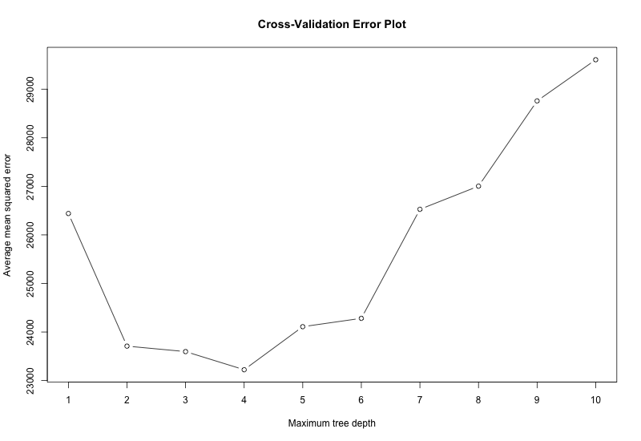

```julia
using Plots
using RCall

# plotting mean squared error with respect to max_depth
R"""
# open a PNG device
png(filename = "images/hw4_cv_plot.png", width = 800,
height = 550, units = "px")

plot($kfold_errors, type = "b",
     main = "Cross-Validation Error Plot",
     xlab = "Maximum tree depth",
     ylab = "Average mean squared error",
     xaxt="n")
axis(1, at = seq(1, 17))

dev.off()
"""

display("image/png", read("images/hw4_cv_plot.png"))
```

5. Which maximum tree depth would you choose based on the cross-validation results? Why?

I would choose a maximum tree depth of 2, because increasing the depth beyond 2 does not decrease the mean squared error as much as going from a maximum depth of 1 to 2. Although it appears that a maximum tree depth of 4 has the lowest mean squared error, the decrease is not substantial enough to justify increasing the maximum depth from 2 to 4. It is also not part of a broader trend of significantly decreasing mean squared error for steps 2-4, so it does not necessarily mean that a maximum depth of 4 would do a better job at predicting the outcome than a maximum depth of 2. It likely would be overfitting.

6. Fit a regression tree to the full data using the maximum tree depth you chose in the previous question.

```julia
model = fit_regression_tree(features, labels, 2)
```

```
DecisionTreeRegressor
max_depth:                2
min_samples_leaf:         1
min_samples_split:        2
min_purity_increase:      0.0
pruning_purity_threshold: 1.0
n_subfeatures:            0
root:                     Decision Tree
Leaves: 4
Depth:  2
```

7. Plot the fitted tree. Summarize the tree in words. What variables seem to be the most important predictors of the number of per-capita COVID-19 deaths?

```julia
print_tree(model)
```

```
Feature 17 < 13.35 ?
├─ Feature 8 < 13.95 ?
    ├─ 268.93341282634236 : 0/598
    └─ 369.6282717044723 : 0/376
└─ Feature 1 < 27.35 ?
    ├─ 433.635126703255 : 0/1256
    └─ 546.465819762167 : 0/905
```

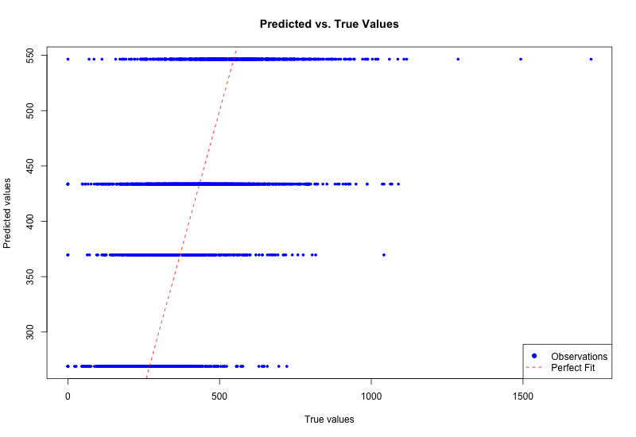

```julia
predicted_labels = predict_tree_label(model, features)

# plotting predicted labels against true labels
R"""
# open a PNG device
png(filename = "images/hw4_predicted_vs_true.png", width = 800,
height = 550, units = "px")

# create scatter plot
plot($labels, $predicted_labels, col="blue", pch=19, cex=0.5,
     main="Predicted vs. True Values",
     xlab="True values",
     ylab="Predicted values")

# Add a line for perfect predictions
abline(0, 1, col="red", lty=2)

# Add a legend
legend("bottomright", legend=c("Observations", "Perfect Fit"), col=c("blue", "red"), pch=c(19, NA), lty=c(NA, 2))

dev.off()
"""

display("image/png", read("images/hw4_predicted_vs_true.png"))
```

There appears to be a lot of variance in the error between true values and predicted values. While the predicted values capture some of the general trends, they are not precise estimates.